# Are You in the Room? A Framework for Sortition and Representation

Daniel Loza

October 27, 2026

# How did I get into this mess?

## Sortition and representation

- Random selection of individuals to form a deliberative panel
- Used since ancient times, recently gaining renewed interest
- Descriptively representative in theory, enabling greater diversity and inclusion
- Selection is typically handled by a fairness-optimising algorithm (today: **LexiMin**), subject to quotas on each trait category

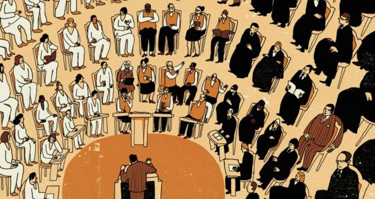

Credit: Oivind Hovland/Ikon/Getty

## The algorithm (LexiMin)

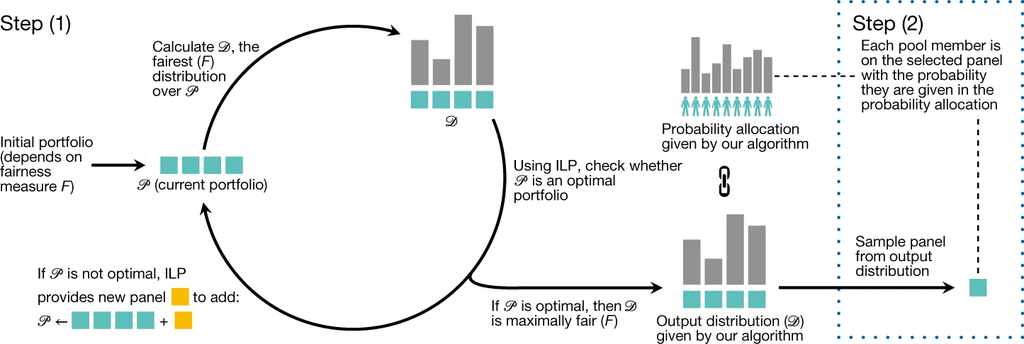

Flanigan et al. (2021)

Step (1): construct a maximally fair output distribution $\mathcal{D}$ over an optimal portfolio $\mathcal{P}$ of quota-compliant panels. Step (2): sample the distribution to select a final panel.

**The question this thesis asks:** satisfying quotas on each trait *separately* guarantees fairness of selection chances – but does it guarantee a panel that actually *looks like* the population, once traits are considered *together*?

# So where in the process do we assess representativeness?

## Simulation design

- Four-stage pipeline: **Population** (n = 100,000) → **Slice** (10% invited) → **Sample** (actual respondents) → **Panel** ($k$ = 50, via LexiMin)
- Two categorical traits: **age** (5 brackets) and **tenure** (Rent/Own/Other)
- Two populations: age & tenure **independent** or **associated** (negative age-renting relationship, via seeding + raking to preserve margins)
- Two response cases: **equal-chance** or **age-associated** (response probability rises with age) → four simulated respondent pools, each run through Panelot’s LexiMin

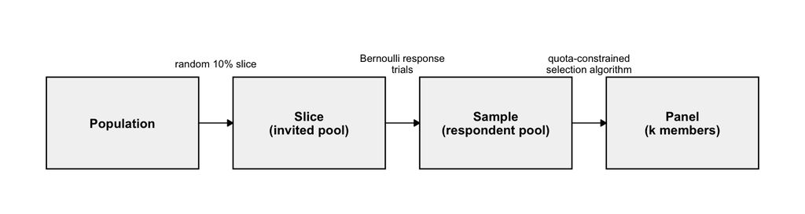

## The problem with current visualisations

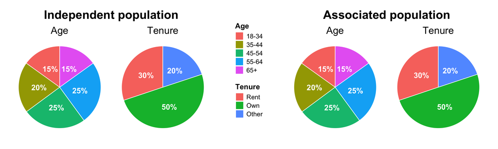

Figure 1

Both populations defined above – notice anything strange?

## How to read a mosaic plot

- **Bar width** = marginal share (equal here: 25 Apple, 25 Orange)
- **Fill height** = proportion of ice cream *given* fruit
- 80% Apple $\rightarrow$ Vanilla; 80% Orange $\rightarrow$ Strawberry
- The fill split **reverses** between bars – a clear association
- If independent, both bars split $\approx$ 50/50 regardless of width

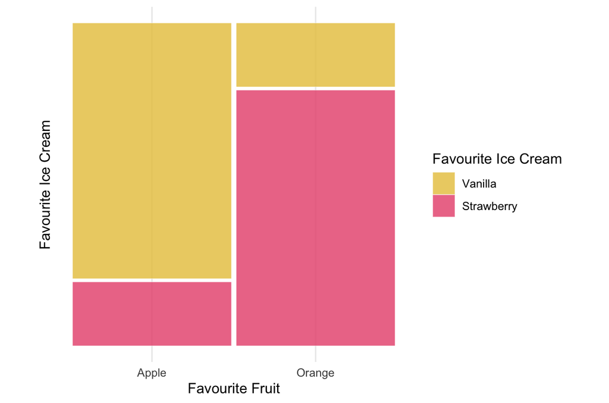

## The pipeline, in practice

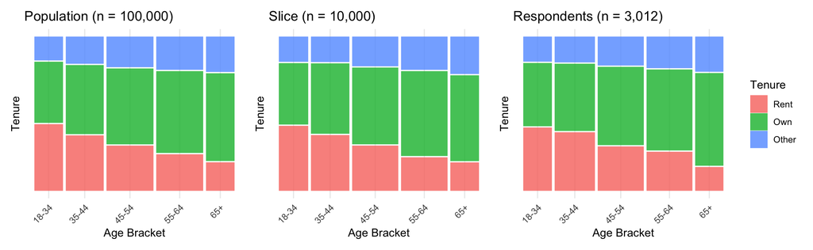

Figure 2

Associated population, equal-chance response: the age-tenure relationship stays smooth and gradual from the population through the slice to actual respondents. It’s only once Panelot selects a panel (next slides) that this breaks down.

## Does the panel preserve the association?

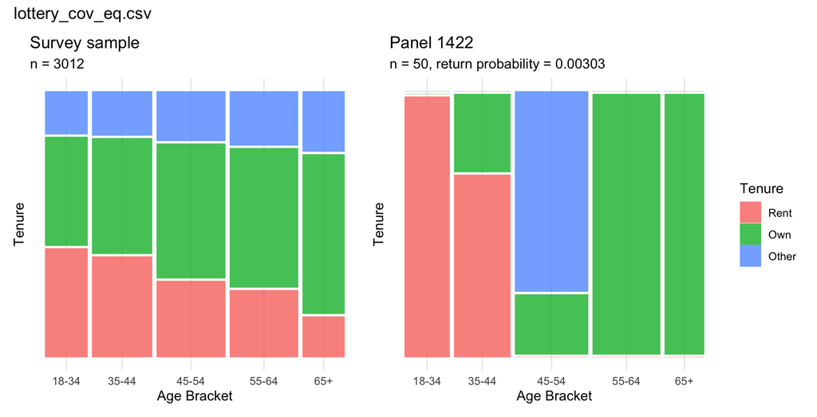

Figure 3

The sample (left) shows a smooth, gradual age-tenure relationship. The panel (right) satisfies the same marginal quotas, but its joint structure is far more blocky and uneven.

## Even with *no* true association…

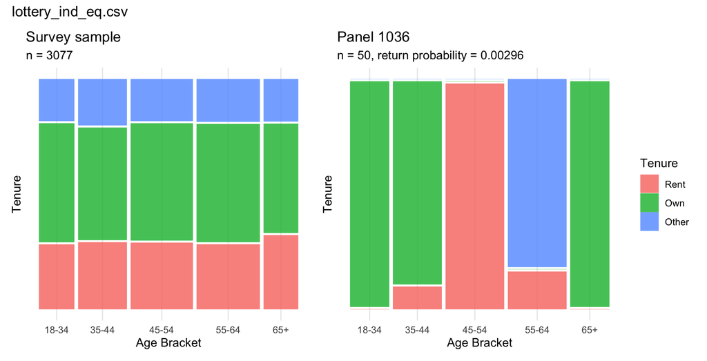

Figure 4

The independent population’s sample is close to flat across age brackets (left) – yet its panel (right) is, if anything, *more* distorted. There is no real association here for the panel to exaggerate: the distortion is a property of the quota mechanism itself.

## The headline result

| Lottery file | Panels | Sample V | Prop. sig. diff. |
| --- | --- | --- | --- |
| ind_eq | 1516 | 0.026 | 1.000 |
| ind_ass | 3483 | 0.030 | 0.998 |
| cov_eq | 1867 | 0.131 | 1.000 |
| cov_ass | 2981 | 0.132 | 0.999 |

- Across **all four** simulated conditions (independent/associated population, equal-chance/age-skewed response), **99.8-100%** of feasible panels show an age-tenure association significantly different from their own sample
- True even for the **independent** population, where there is no association to distort in the first place
- A simple-random-sampling benchmark (500 draws of equal size) is flagged only **8.2-9.4%** of the time – roughly an order of magnitude lower than panels

## Panels vs. random chance

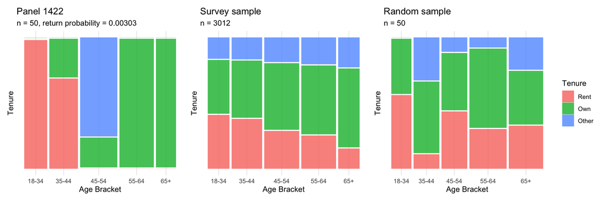

Figure 5

The most likely LexiMin panel (left) and a size-matched random draw (right), anchored against the survey sample they’re both drawn from (middle): the panel’s joint structure is visibly blockier than either, with about **2.9x** the median Cramer’s V of a random draw.

## Why does this happen?

- Quotas set **marginally** – age and tenure counted separately, never jointly
- Meeting every quota says nothing about how categories *combine*
- A panel can hit every quota and still be badly skewed on intersections
- Invisible to standard pie/bar chart reporting

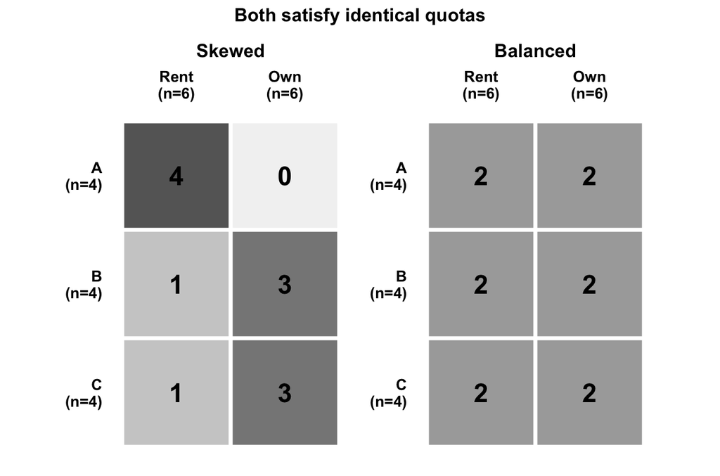

# Introducing Intersection Inspector

## Demo

[Watch the demo video](https://drive.google.com/file/d/14_uLDk7YKTWf6XqL-TCqphr7yGYmxCaX/view?usp=sharing)

## A framework for practitioners

1. **Quota-based selection** – still the right tool for fair marginal chances
2. **Intersectional check** – before convening, not after
3. **Deliberate joint constraints** where a specific intersection matters

Marginal quota satisfaction: **necessary, but not sufficient**.

## Limitations

- Only **two** categorical variables simulated – real panels typically use three or more
- Response rates elevated (30-50%) – a **conservative, best-case** estimate
- Association strengths fixed for visibility, not drawn from real data
- Tool compares **two variables** at a time; levels sorted alphabetically

## Future research

- Extend to **more than two** variables
- Revisit with the **Goldilocks** algorithm once released
- Selection methods with **joint** constraints, not after-the-fact checks

## Reproducibility and Software

Code, data and thesis source available at https://github.com/Pian0Dan/Honours. Analysis in [R](https://www.r-project.org/) with Quarto, using:

- tidyr (Wickham et al. 2025) dplyr (Wickham et al. 2026b) knitr (Xie 2025) ggplot2 (Wickham et al. 2026a)
- patchwork (Pedersen 2025) ggmosaic2 (Friendly et al. 2026) shiny (Chang et al. 2026) kableExtra (Zhu 2026)

# So… am I in the room?

## References

Chang, W., Cheng, J., Allaire, J., Sievert, C., Schloerke, B., Aden-Buie, G., Xie, Y., Allen, J., McPherson, J., Dipert, A., and Borges, B. (2026), *[Shiny: Web application framework for r](https://shiny.posit.co/)*.

Flanigan, B., Gölz, P., Gupta, A., Hennig, B., and Procaccia, A. D. (2021), “[Fair Algorithms for Selecting Citizens’ Assemblies](https://api.semanticscholar.org/CorpusID:236927646),” *Nature*, 596, 548–552.

Friendly, M., Klorfine, G., Jeppson, H., Hofmann, H., and Cook, D. (2026), *[ggmosaic2: Mosaic plots in the ’ggplot2’ framework, extended](https://friendly.github.io/ggmosaic2/)*.

Pedersen, T. L. (2025), *[Patchwork: The composer of plots](https://CRAN.R-project.org/package=patchwork)*.

Wickham, H., Chang, W., Henry, L., Pedersen, T. L., Takahashi, K., Wilke, C., Woo, K., Yutani, H., Dunnington, D., and van den Brand, T. (2026a), *[ggplot2: Create elegant data visualisations using the grammar of graphics](https://ggplot2.tidyverse.org)*.

Wickham, H., François, R., Henry, L., Müller, K., and Vaughan, D. (2026b), *[Dplyr: A grammar of data manipulation](https://dplyr.tidyverse.org)*.

Wickham, H., Vaughan, D., and Girlich, M. (2025), *[Tidyr: Tidy messy data](https://tidyr.tidyverse.org)*.

Xie, Y. (2025), *[Knitr: A general-purpose package for dynamic report generation in r](https://yihui.org/knitr/)*.

Zhu, H. (2026), *[kableExtra: Construct complex table with kable and pipe syntax](https://haozhu233.github.io/kableExtra/)*.